# BigMart Sales Analysis

Ananya Jha

```r
library(tidyverse)
library(here)
```

```r
library(ggplot2)
library(ggthemes)
```

# 1. Introduction

The goal of this project is to uncover business insights by analyzing retail sales from BigMart outlets and identifying the key factors influencing product sales.

The analysis focuses on:

- Sales distribution patterns
- Impact of pricing and visibility
- Outlet performance comparison
- Product category contribution

# 2. Data Overview

```r
data <- read_csv(here("data", "cleaned", "bigmart_cleaned.csv"))
glimpse(data)
```

```
## Rows: 8,523
## Columns: 14
## $ item_identifier           <chr> "FDA15", "DRC01", "FDN15", "FDX07", "NCD19",…
## $ item_weight               <dbl> 9.300, 5.920, 17.500, 19.200, 8.930, 10.395,…
## $ item_fat_content          <chr> "low fat", "regular", "low fat", "regular", …
## $ item_visibility           <dbl> 0.016047301, 0.019278216, 0.016760075, 0.022…
## $ item_type                 <chr> "Dairy", "Soft Drinks", "Meat", "Fruits and …
## $ item_mrp                  <dbl> 249.8092, 48.2692, 141.6180, 182.0950, 53.86…
## $ outlet_identifier         <chr> "OUT049", "OUT018", "OUT049", "OUT010", "OUT…
## $ outlet_establishment_year <dbl> 1999, 2009, 1999, 1998, 1987, 2009, 1987, 19…
## $ outlet_size               <chr> "Medium", "Medium", "Medium", "Unknown", "Hi…
## $ outlet_location_type      <chr> "Tier 1", "Tier 3", "Tier 1", "Tier 3", "Tie…
## $ outlet_type               <chr> "Supermarket Type1", "Supermarket Type2", "S…
## $ item_outlet_sales         <dbl> 3735.1380, 443.4228, 2097.2700, 732.3800, 99…
## $ outlet_age                <dbl> 27, 17, 27, 28, 39, 17, 39, 41, 24, 19, 27, …
## $ price_category            <chr> "Premium", "Low", "High", "High", "Low", "Lo…
```

The dataset contains over 8,500 observations with multiple features related to product characteristics, outlet details, and sales performance.

# 3. Data Cleaning Summary

The dataset required several preprocessing steps:

- Missing values in `item_weight` were imputed using group mean
- Missing `outlet_size` replaced with “Unknown”
- Zero values in `item_visibility` were imputed using group median
- Standardized `item_fat_content` categories
- Converted multiple “character” data types into “factors”
- Created new features:
  - `outlet_age`
  - `price_category`

### Note: Exploratory Analysis Approach

This report presents a selection of key exploratory analyses and visualizations. The complete analysis, including detailed EDA and intermediate outputs, is available in the scripts/ directory.

The focus of this report is to highlight the most relevant insights and business-critical patterns derived from the data.

# 4. Exploratory Data Analysis (EDA)

### 4.1 Univariate Analysis

```r
summary(data$item_outlet_sales)
```

```
##     Min.  1st Qu.   Median     Mean  3rd Qu.     Max.
##    33.29   834.25  1794.33  2181.29  3101.30 13086.96
```

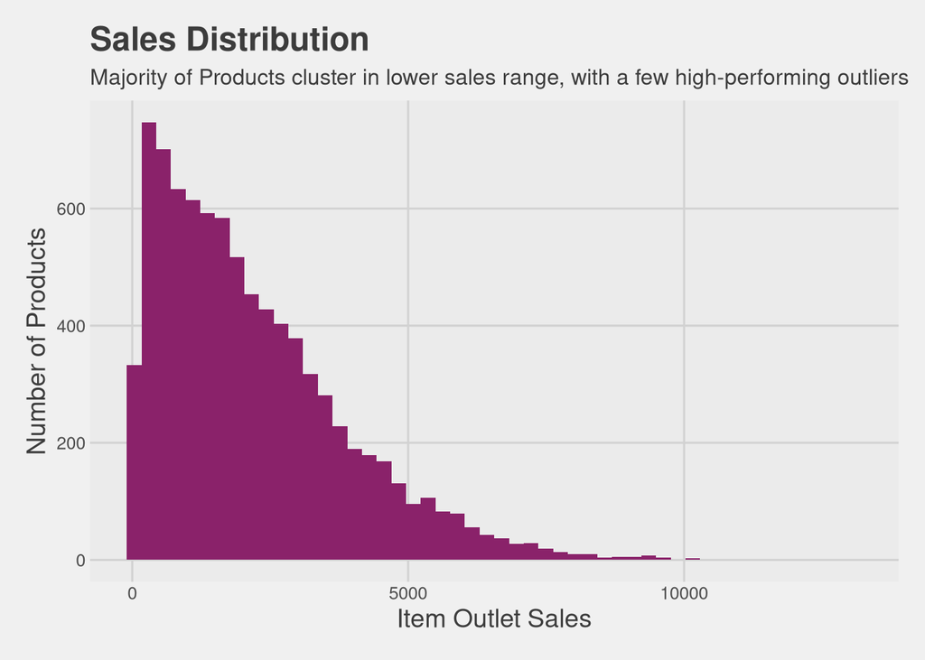

```r
data %>%
  ggplot(aes(x = item_outlet_sales)) +
  geom_histogram(fill = "#8A226AFF", bins = 50) +
  labs(
    title = "Sales Distribution",
    subtitle = "Majority of Products cluster in lower sales range, with a few high-performing outliers",
    x = "Item Outlet Sales",
    y = "Number of Products",
  ) +
  theme_fivethirtyeight() +
  theme(
    text = element_text(family = "sans"),
    plot.title = element_text(face = "bold", size = 18),
    axis.title = element_text(size = 14),
    axis.text = element_text()
  )
```

The sales variable shows a wide distribution with a right-skew, indicating that a small number of products generate significantly higher revenue compared to the majority.

### 4.2 Bivariate Analysis

#### Sales by Outlet Type

```r
sales_by_outlet <- data %>%
  group_by(outlet_type) %>%
  summarise(avg_sales = mean(item_outlet_sales, na.rm = TRUE),
            total_sales = sum(item_outlet_sales)) %>%
  ungroup()
```

Different outlet types show significant variation in total sales, suggesting that store format plays a key role in performance.

#### Sales by Location

```r
sales_by_location <- data %>%
  group_by(outlet_location_type) %>%
  summarise(avg_sales = mean(item_outlet_sales, na.rm = TRUE),
            total_sales = sum(item_outlet_sales)) %>%
  ungroup()
```

Sales patterns differ across location tiers, indicating geographical influence on revenue generation.

### 4.3 Multivariate Analysis

#### Outlet Age vs Sales

```r
cor(data$outlet_age, data$item_outlet_sales)
```

```
## [1] 0.04913497
```

The correlation between outlet age and sales is weak, suggesting that older outlets do not necessarily perform better than newer ones.

# 5. Visualizations

### 1. Price vs Sales

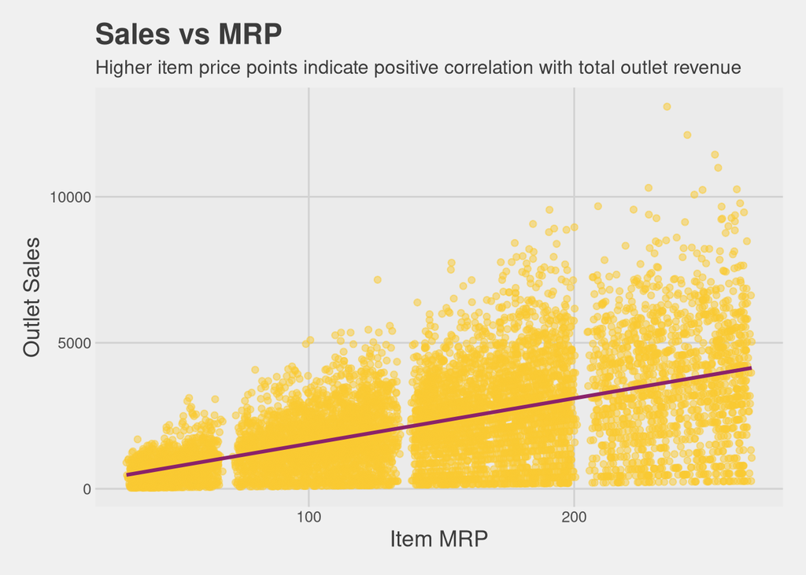

```r
data %>%
  ggplot(aes(x = item_mrp, y = item_outlet_sales)) +
  geom_point(alpha = 0.5, color = "#F9C932FF") +
  geom_smooth(method = "lm", color = "#8A226AFF") +
  labs(
    title = "Sales vs MRP",
    subtitle = "Higher item price points indicate positive correlation with total outlet revenue",
    x = "Item MRP",
    y = "Outlet Sales"
  ) +
  theme_fivethirtyeight() +
  theme(
    text = element_text(family = "sans"),
    plot.title = element_text(face = "bold", size = 18),
    axis.title = element_text(size = 14),
    axis.text = element_text()
  )
```

Higher-priced items tend to generate higher sales, indicating a positive correlation between price and revenue.

### 2. Visibility vs Sales

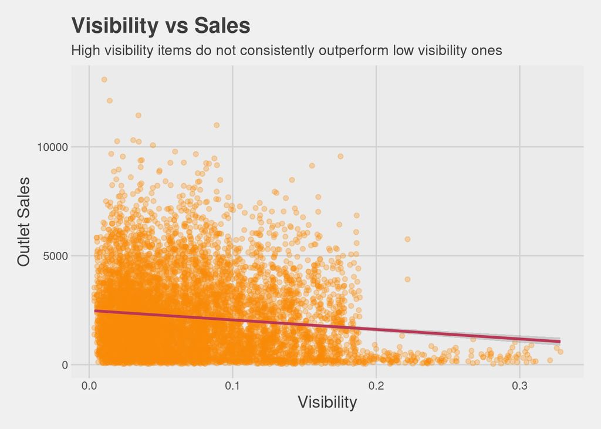

```r
data %>%
  ggplot(aes(x = item_visibility, y = item_outlet_sales)) +
  geom_point(alpha = 0.3, color = "#F98C0AFF") +
  geom_smooth(method = "lm", color = "#BA3655FF") +
  labs(
    title = "Visibility vs Sales",
    subtitle = "High visibility items do not consistently outperform low visibility ones",
    x = "Visibility",
    y = "Outlet Sales"
  ) +
  theme_fivethirtyeight() +
  theme(
    text = element_text(family = "sans"),
    plot.title = element_text(face = "bold", size = 18),
    axis.title = element_text(size = 14),
    axis.text = element_text()
  )
```

Item visibility does not show a strong or consistent impact on sales performance.